# Aula 1: Coisas básicas no R e funções de probabilidade

José Ricardo Inacio Ribeiro

Isso é um [R Markdown](http://rmarkdown.rstudio.com) Notebook depositado no [Bioforum](http://bioforum.wordpress.com). Quando executar o código, os resultados aparecerão abaixo dele!

1. Em primeiro lugar, é interessante você instalar o [Jags para Mac](https://sourceforge.net/projects/mcmc-jags/files/JAGS/4.x/Mac%20OS%20X/JAGS-4.3.0.dmg/download) ou o [OpenBugs para Windows](https://www.mrc-bsu.cam.ac.uk/wp-content/uploads/2018/04/OpenBUGS323setup.zip) em seu computador;
2. Agora, instale também (para usos futuros) os pacotes “rjags” para quem estiver usando Mac e “BRugs” para quem estiver usando Windows;
3. Se tiver problemas de acentuação no RStudio, veja como resolver [aqui](https://support.rstudio.com/hc/en-us/articles/200532197-character-Encoding);
4. Qual é o nosso diretório de trabalho? $\color{red}{\text{Lembre-se que grande parte dos erros cometidos por iniciantes na linguagem R é devido ao mal endereçamento do diretório de trabalho!}}$

```r
#vendo o diretório
getwd()
```

```
## [1] "/Users/joseribeiro/Dropbox/aulas/Bayes/aulas_&_Rmark"
```

```r
#mudando o diretório
setwd('~/Dropbox/aulas/Bayes/')
```

4. O R é uma calculadora antes de tudo!

```r
2 + 3
```

```
## [1] 5
```

```r
4 / 2
```

```
## [1] 2
```

```r
17 %% 3 # o resto de uma divisão! Posso pedir para o R dizer quem é par ou ímpar a partir disso!
```

```
## [1] 2
```

*Note que os resultados aparecerão em uma linha diferente, começando com [1]. Esse número entre os dois colchetes dá o endereço do primeiro item na linha.*

5. Vamos, agora, atribuir um valor a um objeto. A linguagem R é uma linguagem **direcionada a objetos!**

```r
#usamos o operador <-
a <- 17 %% 3
a
```

```
## [1] 2
```

```r
a * 2
```

```
## [1] 4
```

6. Gerando sequências regulares:

```r
1 : 40
```

```
##  [1]  1  2  3  4  5  6  7  8  9 10 11 12 13 14 15 16 17 18 19 20 21 22 23 24 25
## [26] 26 27 28 29 30 31 32 33 34 35 36 37 38 39 40
```

```r
1 : 40 * 2
```

```
##  [1]  2  4  6  8 10 12 14 16 18 20 22 24 26 28 30 32 34 36 38 40 42 44 46 48 50
## [26] 52 54 56 58 60 62 64 66 68 70 72 74 76 78 80
```

```r
1 : (40 * 2)
```

```
##  [1]  1  2  3  4  5  6  7  8  9 10 11 12 13 14 15 16 17 18 19 20 21 22 23 24 25
## [26] 26 27 28 29 30 31 32 33 34 35 36 37 38 39 40 41 42 43 44 45 46 47 48 49 50
## [51] 51 52 53 54 55 56 57 58 59 60 61 62 63 64 65 66 67 68 69 70 71 72 73 74 75
## [76] 76 77 78 79 80
```

7. Se algo ficar muito difícil, você pode evocar o *help* de uma coisa qualquer no R com **?** ou a expressão **help( )**:

```r
?sqrt
?lm
help(lm)
```

8. Já que falamos em expressões, introduzo aqui a ideia de função. Uma função é *uma rotina escrita em linguagem R que pode já estar no ambiente R, vindo de um pacote qualquer, ou que pode ser criada pelo usuário!* Na verdade, **tudo pode ser construído no R!**

```r
#Uma função normalmente retorna um ou vários objetos. Ao usarmos uma função, não devemos esquecer de abrir e fechar os parênteses e, entre eles, devemos especificar as opções ou argumentos (que na verdade são outros objetos) separados por vírgula:
sqrt(4) #raiz-quadrada de 4
```

```
## [1] 2
```

```r
#Funções bult-in constantes:
pi #valor de pi
```

```
## [1] 3.141593
```

```r
LETTERS #letras maiúsculas do alfabeto
```

```
##  [1] "A" "B" "C" "D" "E" "F" "G" "H" "I" "J" "K" "L" "M" "N" "O" "P" "Q" "R" "S"
## [20] "T" "U" "V" "W" "X" "Y" "Z"
```

```r
#a função c combina elementos em um vetor...
c(10, 15, 18)
```

```
## [1] 10 15 18
```

```r
a <- c(10, 16, 1:10)
#mostrando o que tem dentro de a...
a
```

```
##  [1] 10 16  1  2  3  4  5  6  7  8  9 10
```

```r
#pegando o tamanho e o que é a:
length(a)
```

```
## [1] 12
```

```r
mode(a)
```

```
## [1] "numeric"
```

```r
# Minha primeira função no R:
doSum <- function(a, b, c){
    s <- a + b + c
    return(s)
    }
Res <- doSum(1, 2, 3) #soma dos valores 1, 2 e 3
med <- mean(Res) #média de Res
```

9. Exitem funções no R que extraem valores de uma **distribuição qualquer**.

```r
dez_vals <- rnorm(10) #dez números aleatórios de uma distribuição normal
x.norm <- rnorm(1500, 10, 2) #mil e quinhentos números aleatórios de uma distribuição normal com a média igual a 10 e desvio-padrão igual a 2.
```

10. Existem vários modos em linguagem R: *numeric, characters, logicals, and list*.

```r
#Podemos usar operadores de comparação e vetores lógicos:
a == 10 #repare no sinal de igual!
```

```
##  [1]  TRUE FALSE FALSE FALSE FALSE FALSE FALSE FALSE FALSE FALSE FALSE  TRUE
```

```r
a <= 10 #isso significa menor ou igual
```

```
##  [1]  TRUE FALSE  TRUE  TRUE  TRUE  TRUE  TRUE  TRUE  TRUE  TRUE  TRUE  TRUE
```

```r
mode(a <= 5)
```

```
## [1] "logical"
```

```r
#pode-se combinar condições usando operadores booleanos:
a < 5 | a > 10 #or
```

```
##  [1] FALSE  TRUE  TRUE  TRUE  TRUE  TRUE FALSE FALSE FALSE FALSE FALSE FALSE
```

```r
a > 5 & a < 10 #and
```

```
##  [1] FALSE FALSE FALSE FALSE FALSE FALSE FALSE  TRUE  TRUE  TRUE  TRUE FALSE
```

```r
#pode-se obter as posições (índices) do elemento no vetor que são "TRUE"...
which(a > 5 & a < 10)
```

```
## [1]  8  9 10 11
```

11. Podemos usar os colchetes para indexar ou selecionar elementos dentro de um objeto;

```r
a[2] # segundo elemento de a (no R, a contagem começa em 1!)
```

```
## [1] 16
```

```r
a[-2] # mostra tudo, exceto o segundo elemento de a (no R, a contagem começa em 1!)
```

```
##  [1] 10  1  2  3  4  5  6  7  8  9 10
```

```r
a[2:6] # mostra os elementos da posição 2 à posição 6 de a (no R, a contagem começa em 1!)
```

```
## [1] 16  1  2  3  4
```

12. Objetos de diferentes modos podem ser agrupados em uma lista:

```r
b <- c("juju", "jojo")
mode(b)
```

```
## [1] "character"
```

```r
a2 <- c(a, b)
a2
```

```
##  [1] "10"   "16"   "1"    "2"    "3"    "4"    "5"    "6"    "7"    "8"
## [11] "9"    "10"   "juju" "jojo"
```

```r
mode(a2)
```

```
## [1] "character"
```

```r
a2 <- list(a, b)
a2
```

```
## [[1]]
##  [1] 10 16  1  2  3  4  5  6  7  8  9 10
##
## [[2]]
## [1] "juju" "jojo"
```

```r
#para indexar uma lista, é necessário usar [[]]:
a2[[2]]
```

```
## [1] "juju" "jojo"
```

```r
length(a2)
```

```
## [1] 2
```

```r
mode(a2)
```

```
## [1] "list"
```

13. Indexando-se por nomes:

```r
#Pode-se fornecer nomes para cada elemento de um vetor ou uma lista:
a2 <- list("primeiro" = a, "segundo" = b) #reparem nesse sinal de igual!
names(a2) #names: função para obter o nome de diferentes valores contido em um objeto
```

```
## [1] "primeiro" "segundo"
```

```r
#o operador $ permite extrair os valores correspondentes a um dado nome em uma lista (ou em uma tabela, ou em um vetor)
#a2$primeiro
```

```r
#Podemos fazer o mesmo para vetores:
a <- letters[1:10] #alguns objetos, em linguagem R, existem independentemente de nós os termos criados, como por exemplo letters, LETTERS e pi
object1 <- 1:10 * 2
names(object1) <- a
object1
```

```
##  a  b  c  d  e  f  g  h  i  j
##  2  4  6  8 10 12 14 16 18 20
```

```r
names(object1)
```

```
##  [1] "a" "b" "c" "d" "e" "f" "g" "h" "i" "j"
```

```r
mode(object1)
```

```
## [1] "numeric"
```

```r
#b$d #note que não é possível usar "name" para indexar vetores
```

14. Indexadores lógicos, os quais retornam os valores quando a condição é *TRUE*:

```r
a[a != "b"] #para falar que algo deve ser diferente de, é necessário o uso de ! ("not")
```

```
## [1] "a" "c" "d" "e" "f" "g" "h" "i" "j"
```

```r
object1[object1 > 5 & object1 < 9]
```

```
## c d
## 6 8
```

```r
#repare nisso: temos algo que não é o mesmo porque foram fornecidos índices (não as condições)
object1[6:8]
```

```
##  f  g  h
## 12 14 16
```

## Como produzir dados no R:

```r
# gerando vetores...
rep(2, 10)
```

```
##  [1] 2 2 2 2 2 2 2 2 2 2
```

```r
seq(2, 7, by = 2)
```

```
## [1] 2 4 6
```

```r
seq(2, 7, length = 2)
```

```
## [1] 2 7
```

```r
# gerando matrizes...
M <- matrix(1:10, 5, 2) #o primeiro argumento correponde aos elementos, o segundo ao número de linhas,
# e o terceiro ao número de colunas
matrix(1:10, 2, 5)
```

```
##      [,1] [,2] [,3] [,4] [,5]
## [1,]    1    3    5    7    9
## [2,]    2    4    6    8   10
```

```r
matrix(1:10, 5, 2, byrow = T) #atenção: por padrão o R preenche as matrizes por colunas
```

```
##      [,1] [,2]
## [1,]    1    2
## [2,]    3    4
## [3,]    5    6
## [4,]    7    8
## [5,]    9   10
```

Podemos indexar matrizes…

```r
M <- matrix(1:10, 5, 2)
dim(M) #dá as dimensões de uma matriz
```

```
## [1] 5 2
```

```r
#indexando matrizes => [LINHA, COLUNA]
M[3,1] #linha 3 e coluna 1
```

```
## [1] 3
```

```r
M[,1] #coluna 1
```

```
## [1] 1 2 3 4 5
```

```r
M[2,] #linha 2
```

```
## [1] 2 7
```

```r
#gerando arrays (matrizes expandidas)...
A <- array(1:24, dim = c(2, 3, 4))
A
```

```
## , , 1
##
##      [,1] [,2] [,3]
## [1,]    1    3    5
## [2,]    2    4    6
##
## , , 2
##
##      [,1] [,2] [,3]
## [1,]    7    9   11
## [2,]    8   10   12
##
## , , 3
##
##      [,1] [,2] [,3]
## [1,]   13   15   17
## [2,]   14   16   18
##
## , , 4
##
##      [,1] [,2] [,3]
## [1,]   19   21   23
## [2,]   20   22   24
```

```r
A[,1,] #[LINHA, COLUNA, MATRIZ]
```

```
##      [,1] [,2] [,3] [,4]
## [1,]    1    7   13   19
## [2,]    2    8   14   20
```

```r
A[1,2,]
```

```
## [1]  3  9 15 21
```

Lidando com variáveis categóricas (ou *fatores*)…

```r
v <- c("blue", "blue", "green", "green", "green")
v
```

```
## [1] "blue"  "blue"  "green" "green" "green"
```

```r
v <- as.factor(v)
v
```

```
## [1] blue  blue  green green green
## Levels: blue green
```

```r
levels(v) #número de níveis
```

```
## [1] "blue"  "green"
```

```r
mode(v)
```

```
## [1] "numeric"
```

```r
#contagem dos valores de v:
table(v)
```

```
## v
##  blue green
##     2     3
```

```r
w <- c(1,1,2,2,2) #transforma em fatores
as.factor(w)
```

```
## [1] 1 1 2 2 2
## Levels: 1 2
```

```r
#factorial indexing
c("blue", "green")[w]
```

```
## [1] "blue"  "blue"  "green" "green" "green"
```

```r
#data frames podem conter diferentes objetos
data1 <- data.frame(v, v2 = c(3, 3, 1.5, 2, 3))
data1
```

```
##       v  v2
## 1  blue 3.0
## 2  blue 3.0
## 3 green 1.5
## 4 green 2.0
## 5 green 3.0
```

```r
#string dá um sumário do data frame
str(data1)
```

```
## 'data.frame':    5 obs. of  2 variables:
##  $ v : Factor w/ 2 levels "blue","green": 1 1 2 2 2
##  $ v2: num  3 3 1.5 2 3
```

```r
#summary sumaria estatísticas descritivas para vetor, data frame ou fator
summary(data1)
```

```
##      v           v2
##  blue :2   Min.   :1.5
##  green:3   1st Qu.:2.0
##            Median :3.0
##            Mean   :2.5
##            3rd Qu.:3.0
##            Max.   :3.0
```

```r
#apagando objetos:
rm(data1)
```

### Agora, queremos colocar um dado dentro do R, a partir do diretório de trabalho…

```r
temperatura <- read.table("~/Dropbox/aulas/Bayes/dados/global_temperature_NASA.txt", sep = "", dec = ".", header = T)
#o argumento sep correponde ao campo separador no arquivo original ("\t" para tab)
temperatura
```

```
##     Year Temperature
## 1   1880       13.81
## 2   1881       13.89
## 3   1882       13.89
## 4   1883       13.80
## 5   1884       13.71
## 6   1885       13.68
## 7   1886       13.68
## 8   1887       13.65
## 9   1888       13.81
## 10  1889       13.88
## 11  1890       13.62
## 12  1891       13.75
## 13  1892       13.72
## 14  1893       13.67
```

[output cut: 124 more lines]

```r
str(temperatura)
```

```
## 'data.frame':    138 obs. of  2 variables:
##  $ Year       : int  1880 1881 1882 1883 1884 1885 1886 1887 1888 1889 ...
##  $ Temperature: num  13.8 13.9 13.9 13.8 13.7 ...
```

```r
head(temperatura)
```

```
##   Year Temperature
## 1 1880       13.81
## 2 1881       13.89
## 3 1882       13.89
## 4 1883       13.80
## 5 1884       13.71
## 6 1885       13.68
```

```r
#vamos selecionar apenas as temperaturas medidas até antes de 1940!
antes_1940 <- temperatura[temperatura[,1] < 1940,]
antes_1940
```

```
##    Year Temperature
## 1  1880       13.81
## 2  1881       13.89
## 3  1882       13.89
## 4  1883       13.80
## 5  1884       13.71
## 6  1885       13.68
## 7  1886       13.68
## 8  1887       13.65
## 9  1888       13.81
## 10 1889       13.88
## 11 1890       13.62
## 12 1891       13.75
## 13 1892       13.72
## 14 1893       13.67
```

[output cut: 46 more lines]

### Vamos produzir novos arquivos agora!

```r
write.table(antes_1940, "antes_1940.txt", row.names = FALSE, quote = F) #CUIDADO: AGORA, O QUE SEPARA AS COLUNAS É ESPAÇO, NÃO TABS!
```

### Podemos aplicar uma função a um objeto:

```r
# a função apply usa o argumento 2 para colunas e 1 para linhas
apply(M, 2, mean)
```

```
## [1] 3 8
```

```r
apply(M, 1, mean)
```

```
## [1] 3.5 4.5 5.5 6.5 7.5
```

### *Loops* e condicionais

```r
for (i in 1:10){
  print(i)
} #for [item] in série-de-itens{
```

```
## [1] 1
## [1] 2
## [1] 3
## [1] 4
## [1] 5
## [1] 6
## [1] 7
## [1] 8
## [1] 9
## [1] 10
```

```r
    #execute uma tarefa
#  }

# loops aninhados:
for (i in 0:5){
  for (a in 0:5){
    print(a)
  }
}
```

```
## [1] 0
## [1] 1
## [1] 2
## [1] 3
## [1] 4
## [1] 5
## [1] 0
## [1] 1
## [1] 2
## [1] 3
## [1] 4
## [1] 5
## [1] 0
## [1] 1
## [1] 2
```

[output cut: 21 more lines]

```r
#para executar iteração:
contador <- 0
while (contador < 10){
  print(contador)
  contador <- contador + 1 #precisamos fazer com que a expressão 1deixe de ser verdadeira em algum momento
} # while (expressão 1) {executar comando até não ser mais verdadeira}
```

```
## [1] 0
## [1] 1
## [1] 2
## [1] 3
## [1] 4
## [1] 5
## [1] 6
## [1] 7
## [1] 8
## [1] 9
```

```r
#condicional IF:
if (5 > 2){
  print('R funciona!')
}
```

```
## [1] "R funciona!"
```

```r
#IF... ELSE
if (1 > 2) {
  print('R funciona!')
} else {
  print('Algo está errado...')
}
```

```
## [1] "Algo está errado..."
```

```r
#ifelse
ifelse(3 > 2, 1, 0) #se 3 > 2, ponha 1, senão 0!
```

```
## [1] 1
```

```r
#operadores lógicos e condicional E
idade <- 13
nome <- 'Bob'
if (idade > 13 & nome == 'Bob'){
  print('Ok Bob, você está autorizado a entrar!')
} #as duas devem ser verdadeiras!

#operadores lógicos e condicional OU
idade <- 12
nome <- 'Bob'
if (idade >= 13 | nome == 'Bob'){
  print('Ok Bob, você está autorizado a entrar!')
} #apenas uma precisa ser verdadeira!
```

```
## [1] "Ok Bob, você está autorizado a entrar!"
```

### Breve introdução a gráficos:

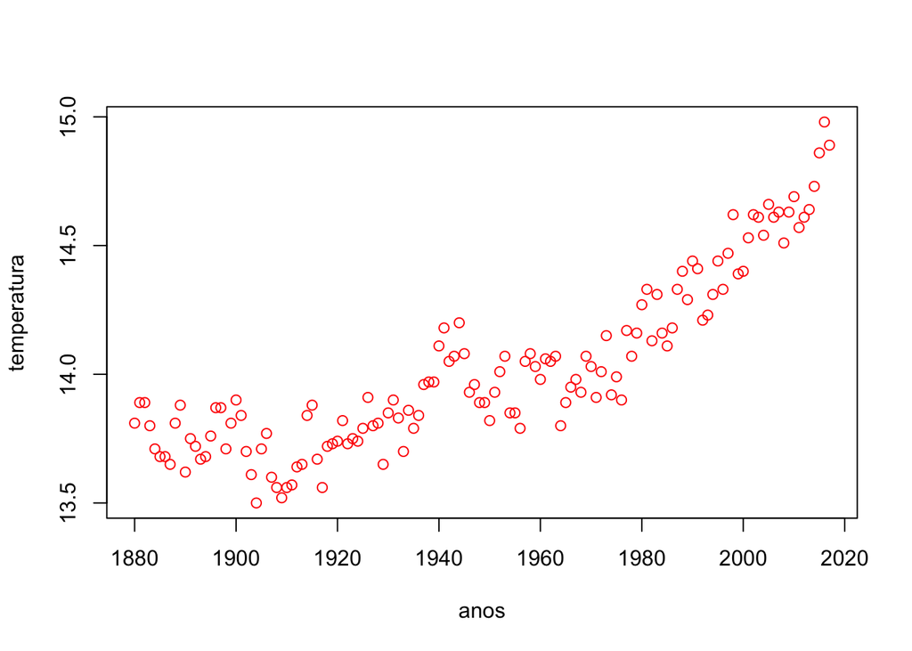

```r
# gráfico de dispersão:
plot(x = temperatura[,1], y = temperatura[,2], lty = 2, col = 'red', xlab = 'anos', ylab = 'temperatura')
```

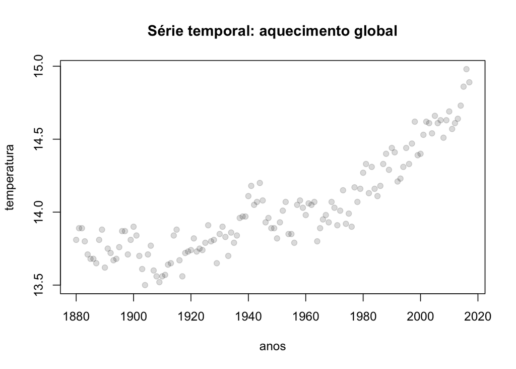

```r
plot(x = temperatura[,1], y = temperatura[,2], col = rgb(0, 0, 0, 0.15), pch = 19, xlab = 'anos',
     ylab = 'temperatura', main = 'Série temporal: aquecimento global')
```

#### $\color{blue}{\text{DESAFIO 1: copie e cole a pasta "Bayes" em seu computador e mude o diretório de trabalho}}$

#### $\color{blue}{\text{para que você possa ter acesso ao diretório.}}$

#### $\color{blue}{\text{DESAFIO 2: selecione apenas as temperaturas medidas antes de 1940 no arquivo global_temperature_NASA.txt}}$

#### $\color{blue}{\text{e produza um novo arquivo com esses dados.}}$

#### $\color{blue}{\text{DESAFIO 3: faça uma função que estime a média das temperaturas medidas do arquivo dado}}$

#### $\color{blue}{\text{(global_temperature_NASA.txt.)}}$

#### $\color{blue}{\text{DESAFIO 4: aplique a função para estimar a média de temperatura depois de 1940.}}$